# Click here to go to Part 2.

# Click here to go to Part 3.

# PART 1

```python
import warnings
warnings.filterwarnings("ignore")
```

```python
# For data loading, manipulation and analysis
import pandas as pd

#For plotting
from matplotlib import pyplot as plt
%matplotlib inline
# For plotting
import seaborn as sns
sns.set_color_codes("dark")
sns.set(font_scale=1)

# For numeric computations
import numpy as np
```

```python
print(pd.__version__) #1.3.0
print(sns.__version__) #0.11.1
print(np.__version__) #1.21.0
```

```
1.3.0
0.11.1
1.21.0
```

```python
df_original = pd.read_csv("Insurance Premium Default-Dataset.csv")
df_original.head()
```

|  | id | perc_premium_paid_by_cash_credit | age_in_days | Income | Count_3-6_months_late | Count_6-12_months_late | Count_more_than_12_months_late | Marital Status | Veh_Owned | No_of_dep | Accomodation | risk_score | no_of_premiums_paid | sourcing_channel | residence_area_type | premium | default |
| --- | --- | --- | --- | --- | --- | --- | --- | --- | --- | --- | --- | --- | --- | --- | --- | --- | --- |
| 0 | 1 | 0.317 | 11330 | 90050 | 0 | 0 | 0 | 0 | 3 | 3 | 1 | 98.810 | 8 | A | Rural | 5400 | 1 |
| 1 | 2 | 0.000 | 30309 | 156080 | 0 | 0 | 0 | 1 | 3 | 1 | 1 | 99.066 | 3 | A | Urban | 11700 | 1 |
| 2 | 3 | 0.015 | 16069 | 145020 | 1 | 0 | 0 | 0 | 1 | 1 | 1 | 99.170 | 14 | C | Urban | 18000 | 1 |
| 3 | 4 | 0.000 | 23733 | 187560 | 0 | 0 | 0 | 1 | 1 | 1 | 0 | 99.370 | 13 | A | Urban | 13800 | 1 |
| 4 | 5 | 0.888 | 19360 | 103050 | 7 | 3 | 4 | 0 | 2 | 1 | 0 | 98.800 | 15 | A | Urban | 7500 | 0 |

```python
# Rename columns as follows
df_original = df_original.rename(columns={'perc_premium_paid_by_cash_credit':'perc_premium_by_cash',
                                        'Count_3-6_months_late':'count3_6',
                                        'Count_6-12_months_late':'count6_12',
                                        'Count_more_than_12_months_late':'count12_more',
                                        'Marital Status':'marital_status',
                                        'Veh_Owned':'vehicles',
                                        'residence_area_type': 'residence',
                                        'Accomodation': 'accomodation',
                                        'No_of_dep':'dependants',
                                        'Income':'income'
                                         })


# The following are some columns that are best regarded as categorical though interger-encoded.
# Converting them as so.
col1 = ['marital_status', 'accomodation',
       'sourcing_channel', 'residence', 'default']
df_original[col1] = df_original[col1].astype('category')

# Make a copy of the DataFrame
df = df_original.copy()
```

```python
# data information
df.info()
```

```
<class 'pandas.core.frame.DataFrame'>
RangeIndex: 79853 entries, 0 to 79852
Data columns (total 17 columns):
 #   Column                Non-Null Count  Dtype
---  ------                --------------  -----
 0   id                    79853 non-null  int64
 1   perc_premium_by_cash  79853 non-null  float64
 2   age_in_days           79853 non-null  int64
 3   income                79853 non-null  int64
 4   count3_6              79853 non-null  int64
 5   count6_12             79853 non-null  int64
 6   count12_more          79853 non-null  int64
 7   marital_status        79853 non-null  category
 8   vehicles              79853 non-null  int64
 9   dependants            79853 non-null  int64
 10  accomodation          79853 non-null  category
 11  risk_score            79853 non-null  float64
 12  no_of_premiums_paid   79853 non-null  int64
 13  sourcing_channel      79853 non-null  category
 14  residence             79853 non-null  category
 15  premium               79853 non-null  int64
 16  default               79853 non-null  category
dtypes: category(5), float64(2), int64(10)
memory usage: 7.7 MB
```

```python
# From the data information above there seems to be no missing information
# but we are going to check some columns (categorical) to ensure that the classes in such columns
# are as expected.

cat_cols = ['marital_status', 'vehicles',
       'dependants', 'accomodation','sourcing_channel', 'residence', 'default']

for col in cat_cols:
    print(col,"--- classes",df[col].unique())

# From the output, the classes are consistent with the data description
```

```
marital_status --- classes [0, 1]
Categories (2, int64): [0, 1]
vehicles --- classes [3 1 2]
dependants --- classes [3 1 4 2]
accomodation --- classes [1, 0]
Categories (2, int64): [0, 1]
sourcing_channel --- classes ['A', 'C', 'B', 'D', 'E']
Categories (5, object): ['A', 'B', 'C', 'D', 'E']
residence --- classes ['Rural', 'Urban']
Categories (2, object): ['Rural', 'Urban']
default --- classes [1, 0]
Categories (2, int64): [0, 1]
```

**Observations**

# EXPLORATORY DATA ANALYSIS

```python
df.describe(include="all")
```

|  | id | perc_premium_by_cash | age_in_days | income | count3_6 | count6_12 | count12_more | marital_status | vehicles | dependants | accomodation | risk_score | no_of_premiums_paid | sourcing_channel | residence | premium | default |
| --- | --- | --- | --- | --- | --- | --- | --- | --- | --- | --- | --- | --- | --- | --- | --- | --- | --- |
| count | 79853.00000 | 79853.000000 | 79853.000000 | 7.985300e+04 | 79853.000000 | 79853.000000 | 79853.000000 | 79853.0 | 79853.000000 | 79853.000000 | 79853.0 | 79853.000000 | 79853.000000 | 79853 | 79853 | 79853.000000 | 79853.0 |
| unique | NaN | NaN | NaN | NaN | NaN | NaN | NaN | 2.0 | NaN | NaN | 2.0 | NaN | NaN | 5 | 2 | NaN | 2.0 |
| top | NaN | NaN | NaN | NaN | NaN | NaN | NaN | 0.0 | NaN | NaN | 1.0 | NaN | NaN | A | Urban | NaN | 1.0 |
| freq | NaN | NaN | NaN | NaN | NaN | NaN | NaN | 40032.0 | NaN | NaN | 40030.0 | NaN | NaN | 43134 | 48183 | NaN | 74855.0 |
| mean | 39927.00000 | 0.314288 | 18846.696906 | 2.088472e+05 | 0.248369 | 0.078093 | 0.059935 | NaN | 1.998009 | 2.503012 | NaN | 99.067243 | 10.863887 | NaN | NaN | 10924.507533 | NaN |
| std | 23051.71986 | 0.334915 | 5208.719136 | 4.965826e+05 | 0.691102 | 0.436251 | 0.311840 | NaN | 0.817248 | 1.115901 | NaN | 0.725892 | 5.170687 | NaN | NaN | 9401.676542 | NaN |
| min | 1.00000 | 0.000000 | 7670.000000 | 2.403000e+04 | 0.000000 | 0.000000 | 0.000000 | NaN | 1.000000 | 1.000000 | NaN | 91.900000 | 2.000000 | NaN | NaN | 1200.000000 | NaN |
| 25% | 19964.00000 | 0.034000 | 14974.000000 | 1.080100e+05 | 0.000000 | 0.000000 | 0.000000 | NaN | 1.000000 | 2.000000 | NaN | 98.830000 | 7.000000 | NaN | NaN | 5400.000000 | NaN |
| 50% | 39927.00000 | 0.167000 | 18625.000000 | 1.665600e+05 | 0.000000 | 0.000000 | 0.000000 | NaN | 2.000000 | 3.000000 | NaN | 99.180000 | 10.000000 | NaN | NaN | 7500.000000 | NaN |
| 75% | 59890.00000 | 0.538000 | 22636.000000 | 2.520900e+05 | 0.000000 | 0.000000 | 0.000000 | NaN | 3.000000 | 3.000000 | NaN | 99.520000 | 14.000000 | NaN | NaN | 13800.000000 | NaN |
| max | 79853.00000 | 1.000000 | 37602.000000 | 9.026260e+07 | 13.000000 | 17.000000 | 11.000000 | NaN | 3.000000 | 4.000000 | NaN | 99.890000 | 60.000000 | NaN | NaN | 60000.000000 | NaN |

```
0    50.132118
1    49.867882
Name: marital_status, dtype: float64
```

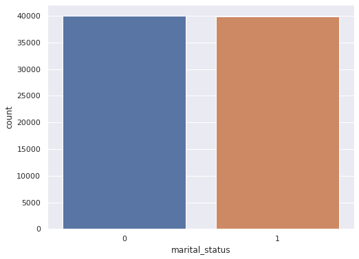

```
0    49.870387
1    50.129613
Name: accomodation, dtype: float64
```

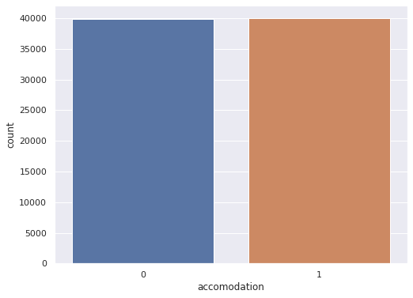

```
A    54.016756
B    20.677996
C    15.076453
D     9.466144
E     0.762651
Name: sourcing_channel, dtype: float64
```

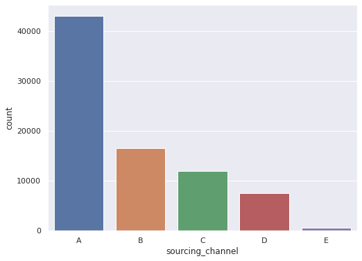

```
Rural    39.660376
Urban    60.339624
Name: residence, dtype: float64
```

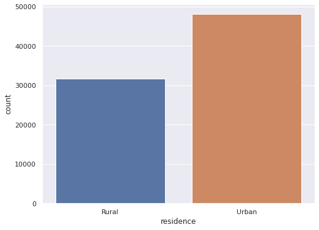

```
0     6.259001
1    93.740999
Name: default, dtype: float64
```

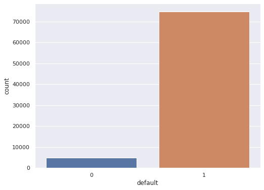

```
0     83.776439
1     11.052810
7      0.028803
2      3.154546
3      1.194695
8      0.018785
4      0.468361
5      0.210387
6      0.085156
13     0.001252
12     0.001252
10     0.001252
9      0.005009
11     0.001252
Name: count3_6, dtype: float64
```

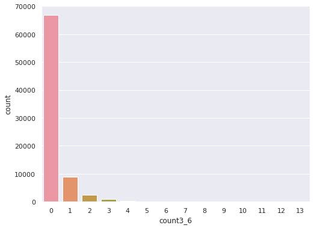

```
0     95.084718
3      0.396979
1      3.356167
4      0.162799
2      0.867845
11     0.002505
5      0.057606
9      0.005009
6      0.032560
8      0.006262
7      0.013775
10     0.005009
14     0.002505
13     0.002505
15     0.001252
17     0.001252
12     0.001252
Name: count6_12, dtype: float64
```

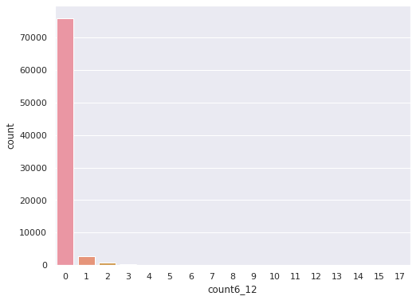

```
0     95.343944
4      0.060110
1      3.751894
2      0.623646
3      0.189097
5      0.016280
8      0.002505
6      0.007514
7      0.003757
11     0.001252
Name: count12_more, dtype: float64
```

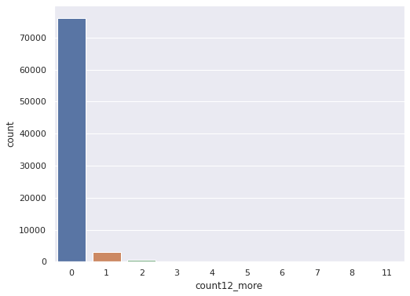

```python
all_categories = ['marital_status', 'accomodation',
                'sourcing_channel', 'residence', 'default',
                'count3_6', 'count6_12',
                'count12_more']

for category in all_categories:
    # Top 5 in each category in terms of count in per cent
    stats = df[category].value_counts(normalize=True, sort=False)*100
    print(stats)
    plt.figure(figsize=(8,6))
    sns.countplot(x=category, data=df)
    plt.show()
```

**Observations:**

- perc_premium_by_cash is the percentage of premium paid by cash. The mean is 31.4% and the third Q is at 53.8% meaning that few customers pays the premium by cash.
- The average age of individuals in the dataset is 18846.7 days with the youngest individual being 7670 and the eldest 37602 days. With the 3rd Q being 22636 days we expect outliers for this attribute. We will transfor this variable later.
- The people, on average, paid a total of 10924 on premium. The maximum paid is 60000 and the minimum premium paid is 1200. The median is 7500 indicating likelihood of having outliers for this attribute. We will investigate that later.
- The mean of income is 208847 and the minimum income is 24030 with the maximum is 90262600 and the median is 166560 a clear indication of skewness. We will investigate this later also.
- On marital_status, 50.1% of the people are unmarried(0) and 49.9% are married.
- risk_score has a min of 91.9% and max of 99.9% with median of mean of 99.07% meaning that most clients are have risk_score near maximum than minimum. Infact 1st Q is at 98.83%.
- count3_6, third Q is 0 implying that most customers are paying the the premium on time. In fact 83.78% of the customers paid the premium on time and the rest delaying at least once. Maximu delay is 13, that is,13 times premium was paid 3-6 months late.
- For count_6-12, 95.1% of the customers paid on time with max of 17 times delay.
- FOr count12_more, 95.3% paid on time with maximum of 11 times in delay.
- The mean number of vehicles owned is 2 with min at 1 and max at 3. This suggest that the insurance policy in this data might involve vehicle insurance cover.
- 60.3% of the customers reside in urban areas and the 39.7% in the rural.
- Majority of customers were source using channel A (54.02%) followed by channel B(20.7) and C coming third with 15.1%. The least of the customers representing 0.76% were sourced using method E.
- Classifications of customers based on accomodation classes is nearly 50-50. 49.87% renting and 50.13% are house owners.
- On no_of_premiums_paid, the max is 60. Inferring from this value and assuming that the premiums are paid monthly, we can hypothersise that the data was collected over a period of 60/12=5 years.
- 93.7% of the customers are non-defaulters.

```python
numerical_cols = list(df.select_dtypes(np.number).columns)
print(numerical_cols)
```

```
['id', 'perc_premium_by_cash', 'age_in_days', 'income', 'count3_6', 'count6_12', 'count12_more', 'vehicles', 'dependants', 'risk_score', 'no_of_premiums_paid', 'premium']
```

```python
# Function to plot histogram and boxplot for numerical variables as we study the
# central tendency and dispersion for such values
def histogram_boxplot(feature, figsize=(10,8), bins = None):
    """
    Boxplot and histogram combined with shared axis
    feature: 1-d feature array
    figsize: size of fig (default (10,8))
    bins: number of bins (default None / auto)
    """

    f2, (ax_box2, ax_hist2) = plt.subplots(nrows = 2, # Number of rows of the subplot grid= 2
                                           sharex = True, # x-axis will be shared among all subplots
                                           gridspec_kw = {"height_ratios": (.25, .75)},
                                           figsize = figsize
                                           ) # creating the 2 subplots
    sns.boxplot(x=feature, ax=ax_box2, showmeans=True, color='red') # boxplot will be created and a star will indicate the mean value of the column
    sns.histplot(x=feature, kde=False, ax=ax_hist2, bins=bins) if bins else sns.histplot(x=feature, kde=False, ax=ax_hist2) # For histogram
    ax_hist2.axvline(np.mean(feature), color='green', linestyle='--') # Add mean to the histogram
    ax_hist2.axvline(np.median(feature), color='black', linestyle='-') # Add median to the histogram
    y_min, y_max = ax_hist2.get_ylim()
    x_min, x_max = ax_hist2.get_xlim()
    print(0.8*max(feature), max(feature))
    print(0.8*y_max, y_max)
    x = 0.8*max(feature)
    y = 0.8*y_max
    if y<y_min:
        y = y_min
    ax_hist2.text(x_max, y, 'Skew: {}'.format(round(feature.skew(),2)), dict(size=15))
    ax_hist2.text(x_max, y-0.1*(y_max), 'Kurtosis: {}'.format(round(feature.kurtosis(),2)), dict(size=15))
```

```
0.8 1.0
8920.800000000001 11151.0
```

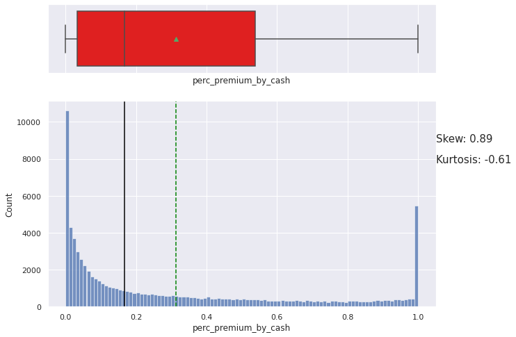

```python
histogram_boxplot(df.perc_premium_by_cash,bins=100)
```

**Observation(perc_premium_by_cash):**

- Median is around 18% and mean roughly 30%. There is a spike at 0% and at 100% for those people who don't pay cash at all and those who pay by cash all the time, respectively.

```
72210080.0 90262600
2542.6800000000003 3178.35
```

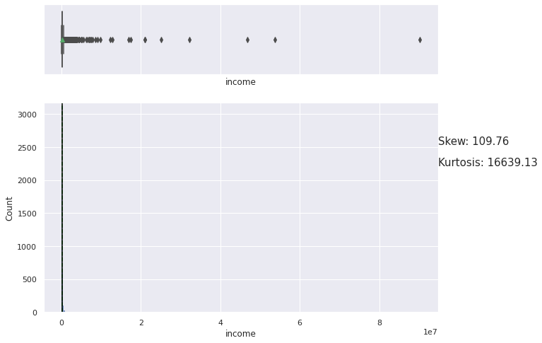

```
919704.0 1149630
2892.1200000000003 3615.15
```

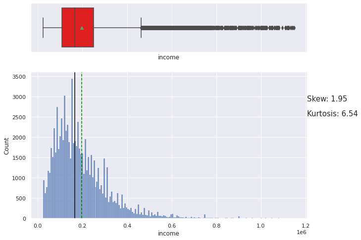

```python
# Income is outrageously highly skewed. The plot is hardly interprateable except for the
# clearly visible outliers.
histogram_boxplot(df.income)
plt.show()

# To make the plot more interpretable we are filtering the data to obtain individuals with
# 1.15 million in Income and below. The plot is now more interpretable but still highly
# skewed to the right.
histogram_boxplot(df[df.income<1150000].income)
plt.show()
```

**Observations(Income):** Income is hightly skewed to the right with the few data points appearing as extreme outliers. This is clearly show with the plot and the skew value of 109.76.

**Observations(Filtered income):** On filtering income to only include data point withs income below 1.15 million the skew significantly drops to 1.95. The plots are now interpretable but still right skewed.

```
79.912 99.89
4282.32 5352.9
```

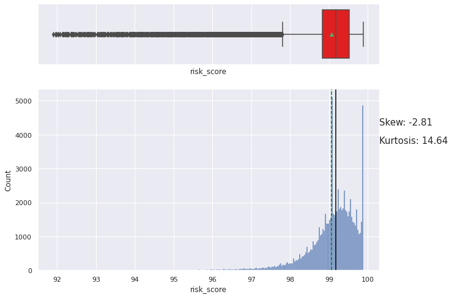

```python
histogram_boxplot(df.risk_score)
```

```
30081.600000000002 37602
5297.040000000001 6621.3
```

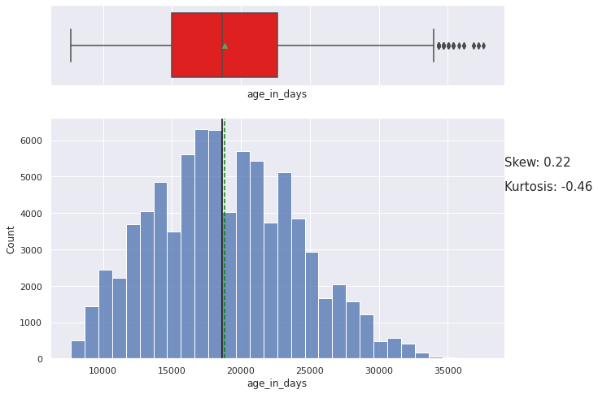

```python
histogram_boxplot(df.age_in_days, bins=30)
```

**Observation(Age):**

- Age is normally distributed but with upper outliers.
- The mean and median of age is around 19000 day.
- Age is positively skewed.

```
48.0 60
11786.04 14732.55
```

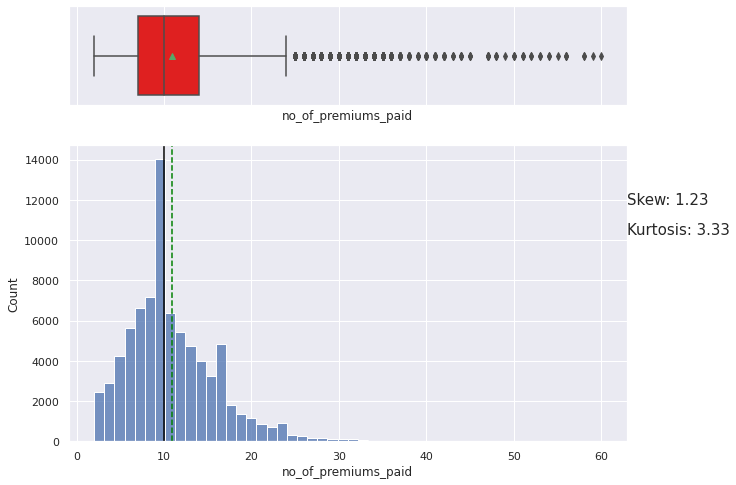

```python
histogram_boxplot(df.no_of_premiums_paid, bins=50)
```

**Observation**

```
48000.0 60000
15634.920000000002 19543.65
```

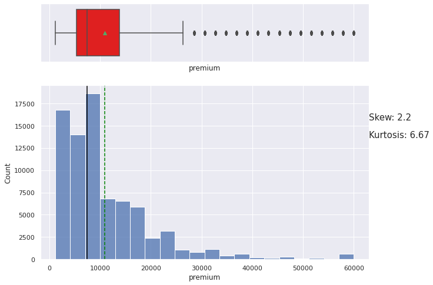

```python
histogram_boxplot(df.premium, bins=20)
```

**Observations (Premium):**

- Right skewed with right outliers.

```
3.2 4
16980.600000000002 21225.75
```

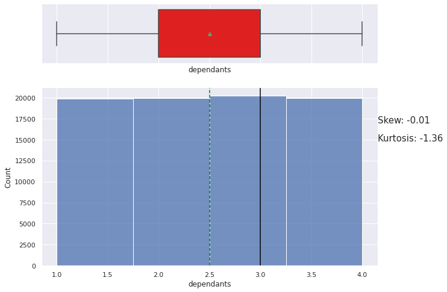

```python
histogram_boxplot(df.dependants, bins=4)
```

**Observation**

The proportion of customers with 1,2,3 and 4 dependents is the same.

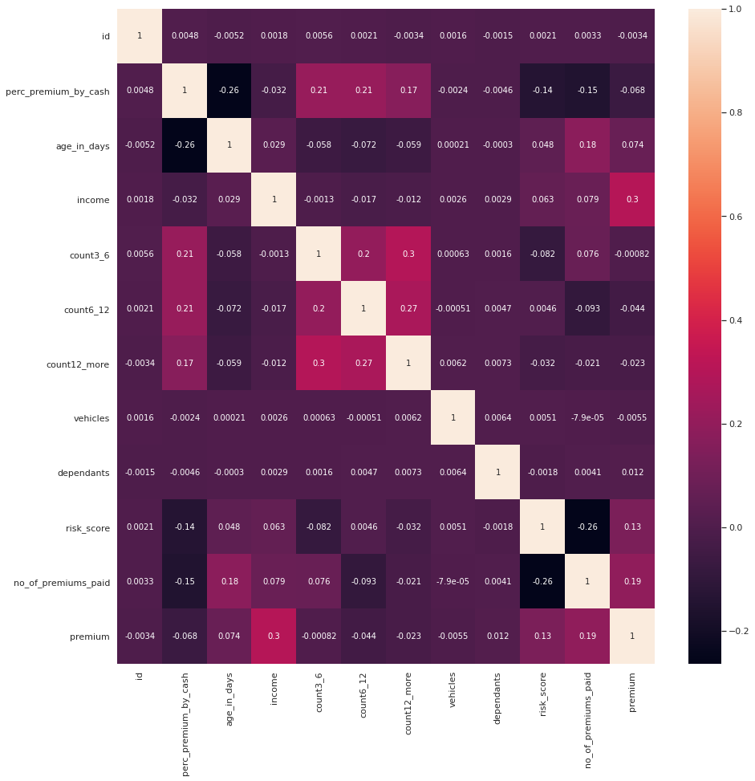

```python
plt.figure(figsize=(15,15))
sns.heatmap(df.corr(), annot=True)
```

**Observations(correlation):**

- There are no numerical attributes that are highly correlated, be it negative or positive.
- It is, however, important to note the following attributes with slight correlation:
  - premium vs income: 0.3 - it is sensible to have this correlation presuming that high income earners will likely pay more premium.
  - no_of_premiums_paid vs premium: 0.19
  - The correlation between late payment classes is also relateable in the sense that an individual who has delayed for 3-6 months will likely delay to 6-12 and even beyound 12 months.
  - There is also a slight correlation between perc_premium_by_cash and the late payment.
  - There is also a slight negative correlation between no_of_premiums_paid and risk score (-0.26) worthnoting.

```
default                  0         1
sourcing_channel
A                 0.054458  0.945542
B                 0.064559  0.935441
C                 0.075006  0.924994
D                 0.083874  0.916126
E                 0.075534  0.924466
```

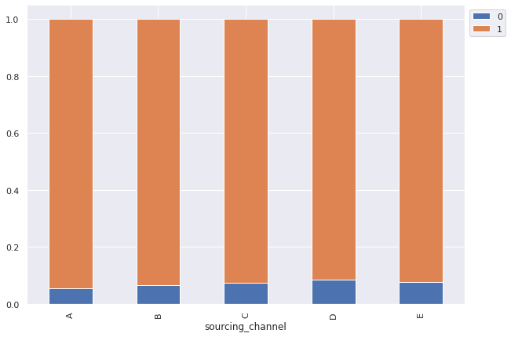

```python
# Default status across sourcing channels
tab1 = pd.crosstab(df.sourcing_channel, df.default, margins=True)
tab2 = pd.crosstab(df.sourcing_channel, df.default, margins=False, normalize='index')
tab2.plot(kind='bar',stacked=True,figsize=(10,7))
print(tab2)
plt.legend(loc='lower left', frameon=False)
plt.legend(loc="upper left", bbox_to_anchor=(1,1));
```

**Observations (Sourcing channel)**

- Sourcing Channels tends to have varying impact on default status..
- Customers sourced from Channel A have the lowest chance of Defaulting
- Customers sourced from Channel D and E have the higher Chance of Defaulting as compared to Channel A
- Customers sourced from D Channel have the highest chance of Defaulting, followed by those from channels C & E, whose risk of Defaulting seems to be the same, followed by those from B, while Customers from A have the lowest risk of Defaulting

```
default                0         1
marital_status
0               0.064224  0.935776
1               0.060948  0.939052
```

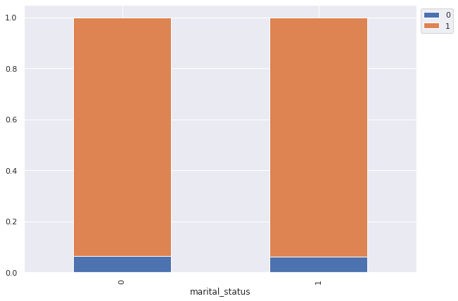

```python
# Default status across marital status
tab1 = pd.crosstab(df.marital_status, df.default, margins=True)
tab2 = pd.crosstab(df.marital_status, df.default, margins=False, normalize='index')
tab2.plot(kind='bar',stacked=True,figsize=(10,7))
print(tab2)
plt.legend(loc='lower left', frameon=False)
plt.legend(loc="upper left", bbox_to_anchor=(1,1));
```

- Marital Status doesn’t seem to have any impact on the whether a customer defauls or not, that is, similar proportion of defaulters exists between the married and the unmarried classes.
- Most of the customers are none defaulters in both classes.

```
default           0         1
residence
Rural      0.063088  0.936912
Urban      0.062263  0.937737
```

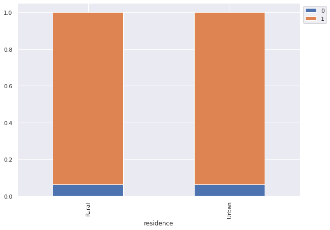

```python
# Default status across residence type!
tab1 = pd.crosstab(df.residence, df.default, margins=True)
tab2 = pd.crosstab(df.residence, df.default, margins=False, normalize='index')
tab2.plot(kind='bar',stacked=True,figsize=(10,7))
print(tab2)
plt.legend(loc='lower left', frameon=False)
plt.legend(loc="upper left", bbox_to_anchor=(1,1));
```

- Residence doesn’t seem to have any significant on chances of default or otherwise.

# PART 2

```python
from matplotlib.ticker import PercentFormatter
```

```python
# Assign our dataframe from part 1 into df2 just convenience of rememberance.
df2 = df.copy()
```

```python
# Tranform variable: Convert age in days to age in years as age
df2["age"] = df2["age_in_days"].apply(lambda x:round(x/365))

# Drop age_in_days and id. id is just equivalent to panda's default index
df2.drop(["age_in_days", "id"], axis=1, inplace=True)
```

```python
df2.head()
```

|  | perc_premium_by_cash | income | count3_6 | count6_12 | count12_more | marital_status | vehicles | dependants | accomodation | risk_score | no_of_premiums_paid | sourcing_channel | residence | premium | default | age |
| --- | --- | --- | --- | --- | --- | --- | --- | --- | --- | --- | --- | --- | --- | --- | --- | --- |
| 0 | 0.317 | 90050 | 0 | 0 | 0 | 0 | 3 | 3 | 1 | 98.810 | 8 | A | Rural | 5400 | 1 | 31 |
| 1 | 0.000 | 156080 | 0 | 0 | 0 | 1 | 3 | 1 | 1 | 99.066 | 3 | A | Urban | 11700 | 1 | 83 |
| 2 | 0.015 | 145020 | 1 | 0 | 0 | 0 | 1 | 1 | 1 | 99.170 | 14 | C | Urban | 18000 | 1 | 44 |
| 3 | 0.000 | 187560 | 0 | 0 | 0 | 1 | 1 | 1 | 0 | 99.370 | 13 | A | Urban | 13800 | 1 | 65 |
| 4 | 0.888 | 103050 | 7 | 3 | 4 | 0 | 2 | 1 | 0 | 98.800 | 15 | A | Urban | 7500 | 0 | 53 |

```python
# Add new variable: income groups
# pandas cut function that can be used to group data in a convenient way

df2["income_groups"] = pd.cut(df2.income, bins=[0, 1e5, 2e5, 3e5, 4e5, 5e5, 6e5, df2.income.max()],\
       labels=["Under100K","100K-200K", "200K-300K", "300K-400K",\
               "400K-500K","500K-600K", "Above600K"])
```

```
Under100K    0.213179
100K-200K    0.398720
200K-300K    0.214983
300K-400K    0.104317
400K-500K    0.033549
500K-600K    0.014715
Above600K    0.020538
Name: income_groups, dtype: float64
```

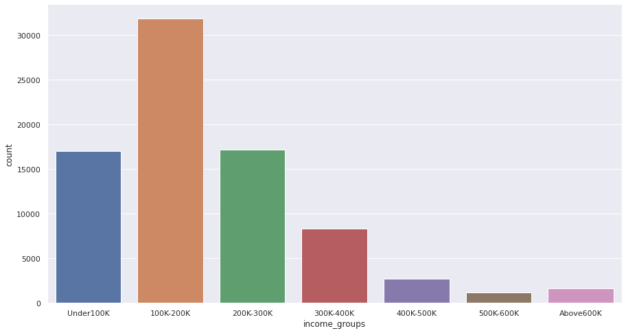

```python
# Distribution of data across age groups
income_g = df2.income_groups.value_counts(sort=False, normalize=True)
print(income_g)

plt.figure(figsize=(15,8))
sns.countplot(x='income_groups', data=df2)
plt.show()
```

**Remark**

- ~21% of the individuals earns below 100K and only ~2% earning above 600 thousand. Majority of the people (39.87%) earns income of between 100K and 200K.

```python
print(income_g.cumsum()) # cumulative sum
```

```
Under100K    0.213179
100K-200K    0.611899
200K-300K    0.826882
300K-400K    0.931199
400K-500K    0.964748
500K-600K    0.979462
Above600K    1.000000
Name: income_groups, dtype: float64
```

**Remark**

- ~21% of the individuals earns below 100K, ~93% below less than 400K and ~97% earns below 600K.

[figure not shown]

```python
# Pareto chart for income groups
x = income_g.sort_values(ascending=False)
cumulative = income_g.cumsum()

fig, ax = plt.subplots(figsize=(15,8))
ax.bar(income_g.index, x, color="C0")
ax2 = ax.twinx()
ax2.plot(income_g.index, cumulative, color="C1", marker="D", ms=7)
ax2.yaxis.set_major_formatter(PercentFormatter())

ax.tick_params(axis="y", colors="C0")
ax2.tick_params(axis="y", colors="C1")
plt.show()
```

```python
# Add new variable- generate agegroups using pandas cut function as used before
df2["age_groups"] = pd.cut(df2.age, bins=[0,20,40,60,80,df2.age.max()],\
       right=True, labels=["Under20","Age20-40", "Age40-60", "Age60-80","Above80"])
```

```
Under20     0.000000
Age20-40    0.240141
Age40-60    0.483113
Age60-80    0.251124
Above80     0.025622
Name: age_groups, dtype: float64
```

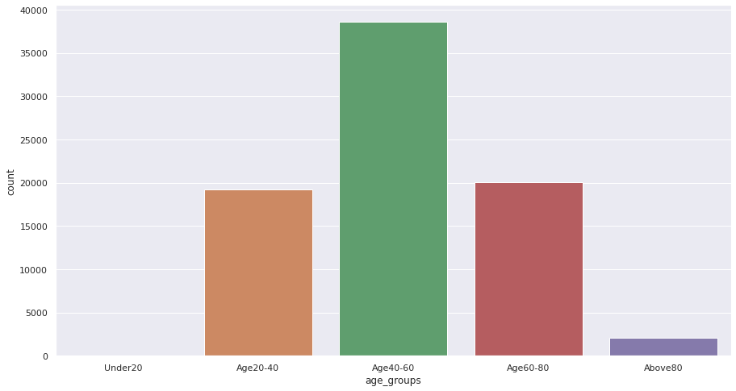

```python
# Distribution of individuals across age groups
age_g = df2.age_groups.value_counts(sort=False, normalize=True)
print(age_g)

plt.figure(figsize=(15,8))
sns.countplot(x='age_groups', data=df2)
plt.show()
```

**Remark(s):**

- There is no one amongst the customers who is under 20 years of age. Majority of the customers making ~48% of all falls on the 40-60 age category. Only 2.6% of the customers are above 80.

```python
print(age_g.cumsum()) # cumulative sum
```

```
Under20     0.000000
Age20-40    0.240141
Age40-60    0.723254
Age60-80    0.974378
Above80     1.000000
Name: age_groups, dtype: float64
```

**Remark**

- There is no one under 20, ~72% of the customers are under 60 and ~97% under 80.

[figure not shown]

```python
# Pareto chart for age groups
x = age_g.sort_values(ascending=False)
cumulative = age_g.cumsum()

fig, ax = plt.subplots(figsize=(15,8))
ax.bar(age_g.index, x, color="C0")
ax2 = ax.twinx()
ax2.plot(age_g.index, cumulative, color="C1", marker="D", ms=7)
ax2.yaxis.set_major_formatter(PercentFormatter())

ax.tick_params(axis="y", colors="C0")
ax2.tick_params(axis="y", colors="C1")
plt.show()
```

```
residence         Rural     Urban
income_groups
Under100K      0.402690  0.597310
100K-200K      0.394233  0.605767
200K-300K      0.397041  0.602959
300K-400K      0.396759  0.603241
400K-500K      0.389324  0.610676
500K-600K      0.389787  0.610213
Above600K      0.390854  0.609146
```

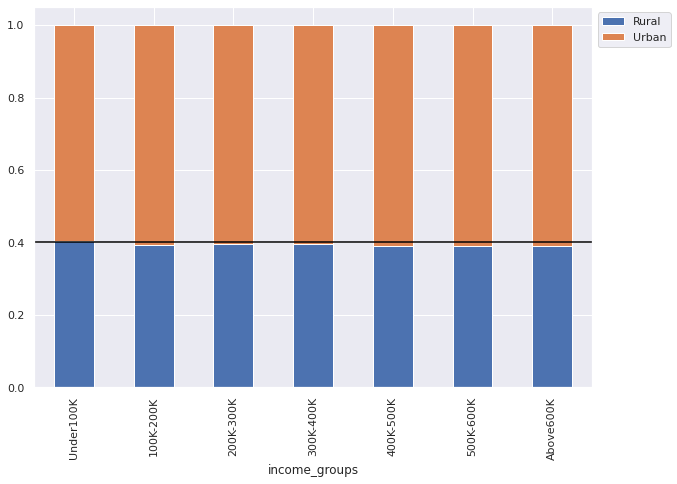

```python
# Default status across sourcing channels
tab1 = pd.crosstab(df2.income_groups, df2.residence, margins=True)
tab2 = pd.crosstab(df2.income_groups, df2.residence, margins=False, normalize='index')
tab2.plot(kind='bar',stacked=True,figsize=(10,7))
print(tab2)
plt.legend(loc='lower left', frameon=False)
plt.axhline(0.4, color='black')
plt.legend(loc="upper left", bbox_to_anchor=(1,1));
```

**Remark:** Around 60% of the customers stays in urban across all income groups. It is, however, notable that people of higher income class have a higher tendency of being in the urban than people in the low income class.

```
vehicles              1         2         3
income_groups
Under100K      0.335370  0.330259  0.334371
100K-200K      0.336286  0.329533  0.334181
200K-300K      0.331450  0.340595  0.327955
300K-400K      0.332293  0.330852  0.336855
400K-500K      0.355356  0.320269  0.324375
500K-600K      0.330213  0.316596  0.353191
Above600K      0.324390  0.349390  0.326220
```

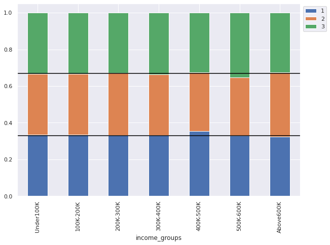

```python
# Default status across sourcing channels
tab1 = pd.crosstab(df2.income_groups, df2.vehicles, margins=True)
tab2 = pd.crosstab(df2.income_groups, df2.vehicles, margins=False, normalize='index')
tab2.plot(kind='bar',stacked=True,figsize=(10,7))
print(tab2)
plt.legend(loc='lower left', frameon=False)
plt.axhline(0.67, color='black')
plt.axhline(0.33, color='black')
plt.legend(loc="upper left", bbox_to_anchor=(1,1));
```

**Remark:** There is no clear trend of number of vehicles across income classes. In each income class, around 30% of the customers have 1, 2 and 3 vehicles.

```
sourcing_channel         A         B         C         D         E
income_groups
Under100K         0.691359  0.160254  0.097456  0.047700  0.003231
100K-200K         0.553221  0.211533  0.146550  0.083043  0.005653
200K-300K         0.470496  0.223510  0.177783  0.117901  0.010310
300K-400K         0.434214  0.223409  0.184754  0.144058  0.013565
400K-500K         0.376260  0.258679  0.200821  0.149683  0.014558
500K-600K         0.378723  0.248511  0.194894  0.167660  0.010213
Above600K         0.368293  0.223171  0.217073  0.171341  0.020122
```

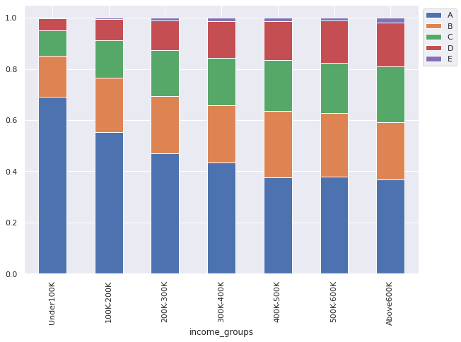

```python
# Default status across sourcing channels
tab1 = pd.crosstab(df2.income_groups, df2.sourcing_channel, margins=True)
tab2 = pd.crosstab(df2.income_groups, df2.sourcing_channel, margins=False, normalize='index')
tab2.plot(kind='bar',stacked=True,figsize=(10,7))
print(tab2)
plt.legend(loc='lower left', frameon=False)
plt.legend(loc="upper left", bbox_to_anchor=(1,1));
```

**Observations:**

```python
income_groups_and_age = df2[['income_groups','age']].groupby(['income_groups']).mean().reset_index()
print(income_groups_and_age)
```

```
  income_groups        age
0     Under100K  49.132115
1     100K-200K  51.461415
2     200K-300K  52.279024
3     300K-400K  53.982233
4     400K-500K  54.496081
5     500K-600K  55.193191
6     Above600K  53.754268
```

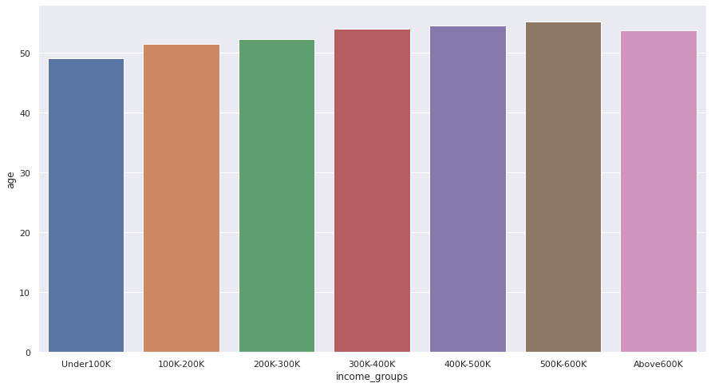

```python
plt.figure(figsize=(15,8))
sns.barplot(x='income_groups', y='age', data=income_groups_and_age)
plt.show()
```

**Remark:** As age increases, income also increases, as expected. This is a general trend.

```python
income_groups_and_premium = df2[['income_groups','premium']].groupby(['income_groups']).mean().reset_index()
income_groups_and_premium
```

|  | income_groups | premium |
| --- | --- | --- |
| 0 | Under100K | 4384.374082 |
| 1 | 100K-200K | 8059.012532 |
| 2 | 200K-300K | 13091.739966 |
| 3 | 300K-400K | 18093.025210 |
| 4 | 400K-500K | 23759.126540 |
| 5 | 500K-600K | 29584.851064 |
| 6 | Above600K | 41009.085366 |